# labTsyntseus

**Convex and Distributed Optimization Lab**  
**MSIAM — Université Grenoble Alpes — 2018/2019**  
**Lecturers: Jérôme Malick, Yassine Laguel, Sélim Chraibi**

**Author(s): Hlib Tsyntseus**

```python
# Automatic reload of local libraries
%load_ext autoreload
%autoreload 2
%reload_ext autoreload
%matplotlib inline
```

> **I. Introduction**  
> **II. The optimization problem**  
> **III. Implementing the solvers**  
> GD (Gradient descent))  
> SGD (Stochastic Gradient Descent))  
> SAGA (Stochastic Average Gradient "Amélioré"))  
> SVRG (Stochastic Variance Reduced Gradient))  
> Comparison  
> **IV. Regularization**  
> **V. Further development**

In this lab, you will implement optimization algorithms that you've studied in class and use them to fit a logistic regression classification model.

You will be implementing a simplified version of [`sklearn.linear_model.LogisticRegression`](https://scikit-learn.org/stable/modules/generated/sklearn.linear_model.LogisticRegression.html).

Part of the work has already been done for you (see the `\lib` folder), so you'll only have to implement the `##### TODO (i) #####` sections of the code. Whenever you complete such a section, we ask you to **copy it in this notebook**. We want you to **only send us a pdf or html export of this notebook** so we won't be able to see your work if it's not in this notebook.

Report in groups of 1 to 3 students.  
**Due date:** Monday, January 6, 2019 (before midnight).  
**Send to:** cdo.grenoble@gmail.com

# I. Introduction

We consider the [Student Performance](http://archive.ics.uci.edu/ml/datasets/Student+Performance) dataset. This dataset contains student demographic, social, school-related features, how many classes they've missed, etc.

The goal we give ourselves is to predict whether a student will pass (final grade > 12).

We denote $A \in \mathcal{M}_{n,d}(\mathbb{R})$ the feature matrix, containing $n$ samples with $d$ features, and $b \in \{-1,1\}^n$ the label vector where $-1$ encodes `fail` and $1$ encodes `pass`.

The data has already been preprocessed (yay less work for you 🎉). You can check `\lib\datasets.py` if you're curious, otherwise, you can just use the following to load your dataset:

```python
import numpy as np
from lib.datasets import load_student_data

A_train, A_test, b_train, b_test = load_student_data('data/student-mat.csv', split=0.25)
```

As mentioned previously, you're going to implement a simplified version of [`sklearn.linear_model.LogisticRegression`](https://scikit-learn.org/stable/modules/generated/sklearn.linear_model.LogisticRegression.html). So let's first see what the finished product should look like.

**Question:**

- Import [sklearn.linear_model.LogisticRegression](https://scikit-learn.org/stable/modules/generated/sklearn.linear_model.LogisticRegression.html) .
- Create an instance of sklearn's logistic regression classifiers with SAGA as its solver.
- Fit the classifier on the training data and compute the score of the fitted model on the test set.

```python
from sklearn.linear_model import LogisticRegression

clf = LogisticRegression(solver='saga', max_iter=500)
clf.fit(A_train, b_train)
clf.score(A_test, b_test)
```

```
0.898989898989899
```

# II. The optimization problem

Logistic regression consists in finding the parameter $x \in \mathbb{R}^d$ that best fits: $$ b_i = \begin{cases} \phantom{-}1 \ \textrm{ if }\ \langle a_{i}, x\rangle \ge 0 \\ -1 \ \textrm{ if }\ \langle a_{i}, x\rangle < 0 \end{cases} $$ for all the samples $i$ of the training set (where $a_i$ is the $i^{th}$ line of $A$ and $b_i$ the $i^{th}$ element of $b$). To measure this fit, logistic regression chooses the following loss:

$$ \textrm{LogisticLoss}(b_i, \left\langle a_{i}, x\right\rangle ) = \log \left(1+\exp \left(-b_{i}\left\langle a_{i}, x\right\rangle\right)\right) $$

The corresponding optimization problem we will consider is the following:

Minimization of the empirical risk $f$ of the $L_2$-regularized logistic regression model, on the dataset $(A_{\textrm{train}},b_{\textrm{train}})$: $$ \begin{aligned} \textrm{min}_{x\in \mathbb{R}^d} \ f(x) \ &= \ \textrm{min}_{x\in \mathbb{R}^d} \ \frac{1}{n_{\textrm{train}}} \sum_{i=1}^{n_{\textrm{train}}} f_i(x) \\ &= \ \textrm{min}_{x\in \mathbb{R}^d}\frac{1}{n_{\textrm{train}}} \sum_{i=1}^{n_{\textrm{train}}} \textrm{LogisticLoss}(b_i, \left\langle a_{i}, x\right\rangle ) + \frac{l_2}{2}\|x\|^{2}_2, \end{aligned} $$ where $l_2 \ge 0$ is the $L_2$ regularization coefficient.

To simplify the notation, we'll stop indexing $A$, $b$ and $n$ with "$\textrm{train}$" in the following.

**Question:** $f$ is $\mu$-strongly convex.

- Give a lower bound on $\mu$.
- Complete **TODO (1)** in **\lib\linear_model.py**.

> **Answer:** $f(x) - \frac{l_2}{2} \lVert x \rVert_2 = \frac{1}{n_{\textrm{train}}} \sum_{i=1}^{n_{\textrm{train}}} \textrm{LogisticLoss}(b_i, \left\langle a_{i}, x\right\rangle )$ is convex, so $f$ has is strongly convex with $\mu \geq l_2$.

**Question:** Denote $\lambda_{\max}$ the largest eigenvalue of the real symmetric matrix $AA^T$.

- Prove that $\lambda_{\max}(\nabla^2 f_i) \le \lambda_{\max}(\frac{a_i a_i^T}{4} + l_2 I_d)$
- Prove that $\lambda_{\max}(a_i a_i^T) \le \|a_i\|^2_2$

> **Answer:** Let us denote $l(x) := \log(1 + \exp(-x))$. Then $\nabla l(b_i <a_i, x> ) = b_i a_i l^{'} (b_i <a_i,x>)$. (We treat $a_i$ as column vectors) $\nabla^2 l(b_i <a_i, x> ) = b_i^2 a_i a^T_i f^{''} (b_i <a_i, x>) = [b_i^2 = 1] = a_i a^T_i f^{''} (b_i <a_i, x>)$

> $l^{'} (x) = -\frac{\exp(-x)}{1 + \exp(-x)} = \frac{1}{1 + \exp(-x)} - 1$, $l^{''} (x) = \frac{\exp(-x)}{(1 + \exp(-x))^2}$, so $\nabla^2 l (b_i<a_i,x>) = a_ia_i^T \frac{\exp(-x)}{(1 + \exp(-x))^2}$. $\nabla^2 f_i(x) = \nabla^2 l(b_i<a_i,x>) + \nabla^2 \frac{l_2}{2} \lVert x \rVert_2^2 = a_ia_i^T \frac{\exp(-x)}{(1 + \exp(-x))^2} + l_2 \textbf{I}_d$

> It obvious (just check the corresponding quadratic form) that $a_i a_i^t \succeq 0$.

> $\frac{a}{(1+a)^2} \leq \frac 1 4 \iff 4a \leq (1+a)^2 \iff 2a \leq 1 + a^2$ and the latter always holds. Then $\frac{\exp(-x)}{(1 + \exp(-x))^2} \leq \frac 1 4$.

> Then $\lambda_{\max}(\nabla^2 f_i) = \lambda_{\max}(a_ia_i^T \frac{\exp(-x)}{(1 + \exp(-x))^2} + l_2 \textbf{I}_d) \leq \lambda_{\max}(\frac{a_i a_i^T}{4} + l_2 I_d)$ $\Big ( A \preceq B \implies \lambda^2_{\max}(A) = \max\limits_{\lVert x \rVert_2 \leq 1} \lVert Ax \rVert^2_2 \leq \max\limits_{\lVert x \rVert_2 \leq 1} \lVert Bx \rVert^2_2 = \lambda^2_{\max}(B) \Big)$.

> $\lambda_{\max}(a_ia_i^T ) = \max\limits_{\lVert x \rVert_2 \leq 1} x^T a_ia_i^T x = \max\limits_{\lVert x \rVert_2 \leq 1}(a_i^T x)^2 = \lVert a_i \rVert^2$ (from Cauchy-Swartz inequality, $|a_i^Tx| \leq \lVert a_i \rVert \lVert x \rVert$ and maximum is attained at $x = \frac{a_i}{\lVert a_i\rVert}$).

A consequence of these results is that the $f_i$s and $f$ are all $L$-smooth with $L \le \frac{\max_i\|a_i\|^2_2}{4} + l_2$ and we can therefore use the following value in our implementation:

```
L = 0.25 * max(np.linalg.norm(A,2,axis=1))**2 + self.l2
```

# III. Implementing the solvers

To implement gradient methods, we need an oracle that will compute both batch gradients $\nabla f$ and partial gradients $\nabla f_i$.

**Question:** In the code below, $\nabla f$ has already been implemented.

- Complete **TODO (2)** bellow.
- Add your code to **\lib\linear_model.py**.

```python
def grad(x, i=None):
    '''
    Gradient of the objective function at x.
    If no i is given, grad should return the batch gradient.
    Otherwise, it should return the partial gradient associated the the datapoint (A[i], b[i]).
    '''

    if i is None: # return batch gradient
        output = -b/(1 + np.exp(b*np.dot(A, x)))
        output = sum(np.diag(output))/n @ A
    else: # return partial gradient associated the datapoint (A[i], b[i])
        output = -b[i]*A[i]/(1 + np.exp(b[i]*(A[i]@x)))
    output += self.l2*x

    return output
```

# GD (Gradient descent)

At iteration k of the GD algorithm, the following update is executed:

$$ x_{k+1} \leftarrow x_{k} - \gamma\nabla f(x_k) $$

**Question:**

- What stepsize $\gamma$ ensures the convergence of this algorithm and under what assumptions?
- Complete **TODO (3)** and **TODO (4)**
- Add your code to **\lib\solvers.py**.

```python
def GD(x0, grad, prox, max_iter, n, L, mu):
    '''
    Parameters
    ----------
    x0: array, shape (nb_features,)
        Initialisation of the solver
    grad: function
        Gradient of the objective function
    max_iter: int
        Number of iterations (i.e. number of descent steps). Note that for GD or SVRG,
        one iteration is one epoch i.e, one pass through the data, while for SGD, SAG and SAGA,
        one iteration uses only one data point.
    n: int
        Dataset size
    L: float
        Smoothness constant of the objective function
    mu: float
        Strong convexity constant of the objective function

    Returns
    -------
    x: array, shape (nb_features,)
        final iterate of the solver
    x_tab: array, shape (nb_features, max_iter)
        table of all the iterates
    '''
    stepsize  = 2.0/(mu+L)
    x         = x0
    x_tab     = np.copy(x)

    for k in range(max_iter):
        x     = prox(x - stepsize*grad(x), stepsize)
        x_tab = np.vstack((x_tab, x))

    return x, x_tab
```

**Question:** Run the code below to test your code.

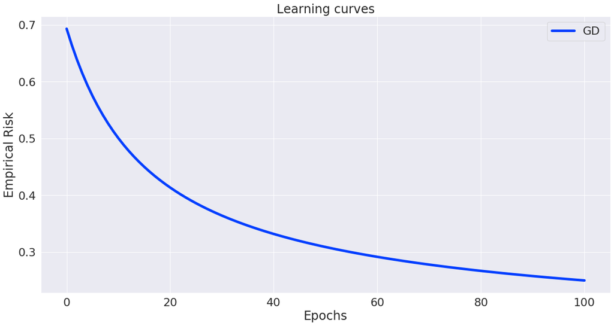

```python
from lib.linear_model import LogisticRegression
from lib.visuals import learning_curve

clf_gd = LogisticRegression(solver='gd', l2=0.01, max_iter=100)
clf_gd.fit(A_train, b_train)

learning_curve(GD=clf_gd)
```

# SGD (Stochastic Gradient Descent)

At iteration k of the SGD algorithm, the following update is executed:

$$ \begin{cases} i \textrm{ chosen randomly in } \{1...n\}\\ x_{k+1} \leftarrow x_{k} - \gamma_k \nabla f_i(x_k) \\ \end{cases} $$

**Question:**

- What stepsize $\gamma_k$ ensures the convergence of this algorithm and under what assumptions?
- Complete **TODO (5)**
- Add your code to **\lib\solvers.py**.

> **Answer:** If $f_i$ ($f$) have L-Lipschitz gradient, gradients are bounded ($\lVert \nabla f_i(x_k) \rVert \leq M$), for $\gamma_k > 0$ s.t. $\gamma_k \to 0$ when $k \to \infty$. $\min_{t = 1 \dots k} \mathbb{E} \big[ \lVert \nabla f(x_k) \rVert \big ]$ goes to 0 as $k$ goes to infinity. Again, under additional assumptions we get stronger results. If $f_i$ are $L$-Lipschitz, $\mu$ - strongly convex (which is the case for logistic regression) we again use decaying stepsize to ensure convergence (e.g. $\gamma_k = \frac {1}{k+1}$), however this time $\mathbb{E} \lVert x_k - x^* \lVert$ converges to zero, where $x^*$ is the minimizer of $f$.

```python
def SGD(x0, grad, prox, max_iter, n, L, mu):
    x         = x0
    x_tab     = np.copy(x)
    c0 = 1.0
    for k in range(max_iter):
        gammak = c0/(k+1)
        i = np.random.randint(low=0, high=n)
        x = prox(x - gammak*grad(x,i=i), gammak)
        if k%n == 0: # each completed epoch
            x_tab = np.vstack((x_tab, x))
    return x, x_tab
```

**Question:** Run the code below to test your code.

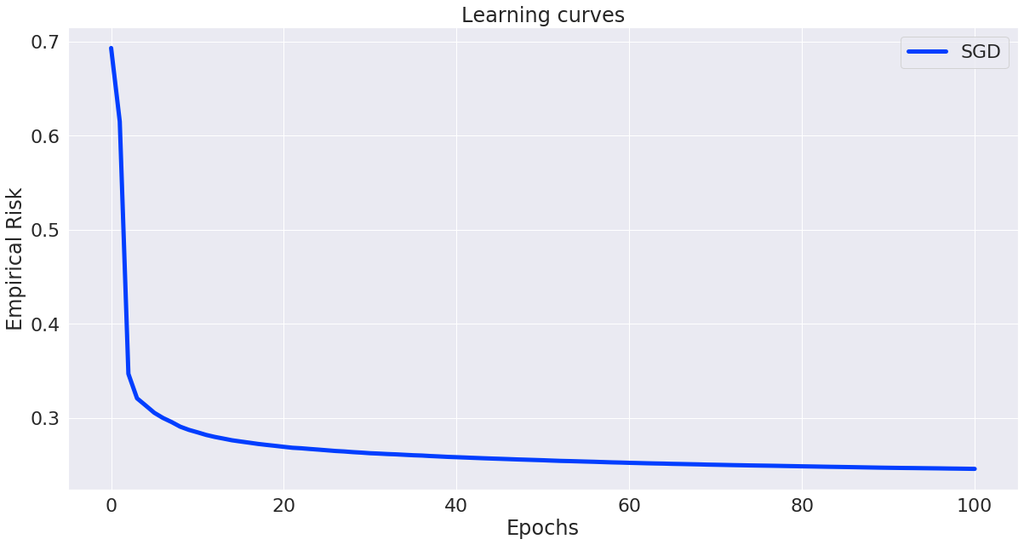

```python
clf_sgd = LogisticRegression(solver='sgd', l2=0.01, max_iter=100*len(b_train))
clf_sgd.fit(A_train, b_train)

learning_curve(SGD=clf_sgd)
```

# SAGA (Stochastic Average Gradient "Amélioré")

SAGA starts by computing a single batch gradient, then at iteration k, the following update is executed:

$$ \begin{cases} i \textrm{ chosen randomly in } \{1...n\}\\ x_{k+1} \leftarrow x_{k} - \gamma_k\big(\nabla f_i(x_k) - \alpha_i + \bar{\alpha}\big) \\ \alpha_i \leftarrow \nabla f_i(x) \end{cases} $$

where $(\alpha_j)_{j=1}^n$ are gradients evaluated at previous iterates and $\bar{\alpha}=\frac{1}{n}\sum^n_{j=1}\alpha_j$.

**Question:**

- What stepsize $\gamma_k$ ensures the convergence of this algorithm and under what assumptions?
- Complete **TODO (6)**
- Add your code to **\lib\solvers.py**.

```python
def SAGA(x0, grad, prox, max_iter, n, L, mu):
    ######## TODO (6) ########
    x = np.copy(x0)
    x_tab = np.copy(x)
    gamma = 0.5/(mu*n + L)
    grad_stored = [grad(x, i) for i in range(n)]
    stored_average = np.sum(grad_stored,axis=0)/n
    for k in range(max_iter):
        i = np.random.randint(n)
        grad_upd = grad(x,i)
        x = prox(x - gamma*(grad_upd - grad_stored[i] + stored_average), gamma)
        stored_average = stored_average - grad_stored[i]/n + grad_upd/n
        grad_stored[i] = grad_upd
        if k%n == 0: # each completed epoch
            x_tab = np.vstack((x_tab, x))

    return x, x_tab
```

**Question:** Run the code below to test your code.

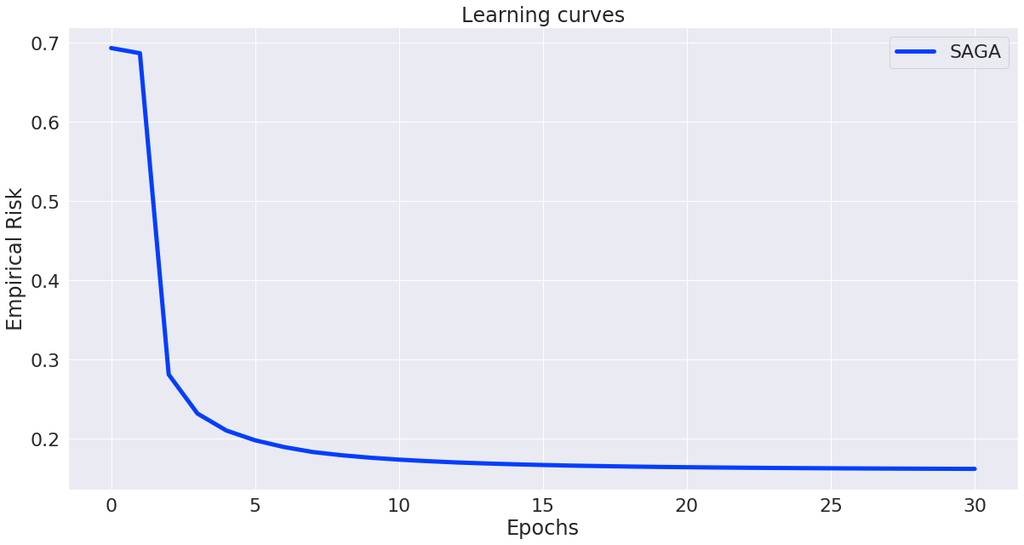

```python
clf_saga = LogisticRegression(solver='saga', l2=0.01, max_iter=30*len(b_train))
clf_saga.fit(A_train, b_train)

learning_curve(SAGA=clf_saga)
```

# SVRG (Stochastic Variance Reduced Gradient)

At iteration k of the SVRG algorithm, we perform the following:

$$ \begin{cases} \textrm{Compute the batch gradient } \nabla f(x_k)\\ \textrm{Initialise }y_0 = x_k\\ \textrm{for m in 0...M-1: } \begin{cases} i \textrm{ chosen randomly in } \{1...n\} \\ y_{m+1} \leftarrow y_{m} - \gamma_k\big(\nabla f_i(y_m) - \nabla f_i(x_k) + \nabla f(x_k)) \end{cases}\\ x_{k+1} \leftarrow y_{M} \end{cases} $$

**Question:**

- What stepsize $\gamma_k$ ensures the convergence of this algorithm and under what assumptions?
- Complete **TODO (7)**
- Add your code to **\lib\solvers.py**.

> **Answer:** Under the assumption that $f_i$ are L-Lipschitz and $f$ is $\mu$-strongly convex, for $\gamma_k = \gamma$ s.t.  
> $0 < \gamma < \frac{1}{4L}$, and $ M > \frac{1 + 4\mu\gamma^2}{1 - 4\gamma L - 4 \gamma^2\mu}$ then $\mathbb{E} \lVert x_k - x^* \rVert \to 0$ when $k \to \infty$ and convergence is linear.

```python
def SVRG(x0, grad, prox, max_iter, n, L, mu):
    x = np.copy(x0)
    y = np.copy(x)
    x_tab = np.copy(x)
    gamma = 0.5/(4* L)
    M = int(np.ceil((1 + 4*mu*gamma**2)/(1-4*gamma*L - 4*gamma**2*mu)))+1
    print('M', M)
    for k in range(max_iter):
        grad_full = grad(x)
        for m in range(M):
            i = np.random.randint(n)
            y = prox(y - gamma*(grad(y,i) - grad(x,i) + grad_full), gamma)
            if (M*k + m) % n == 0:
                x_tab = np.vstack((x_tab, y))
        x = y

    return x, x_tab
```

**Question:** Run the code below to test your code.

```
M 4
```

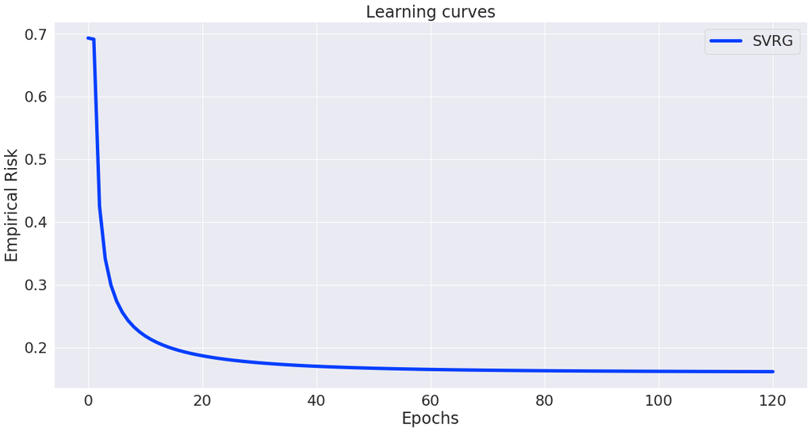

```python
clf_svrg = LogisticRegression(solver='svrg', l2=0.01, max_iter=30*len(b_train))
clf_svrg.fit(A_train, b_train)

learning_curve(SVRG=clf_svrg)
```

# Comparison

**Question:** Run the code below to compare all the methods you've implemented.

```python
epochs = 50
n = len(b_train)

M = 4 # number of iterations in the inner loop of svrg, need for plots

clf_gd   = LogisticRegression(solver='gd', l2=0.01, max_iter=epochs)
clf_sgd  = LogisticRegression(solver='sgd', l2=0.01, max_iter=epochs*n)
clf_saga = LogisticRegression(solver='saga', l2=0.01, max_iter=epochs*n)
clf_svrg = LogisticRegression(solver='svrg', l2=0.01, max_iter=epochs*n//M)

clf_gd.fit(A_train, b_train)
clf_sgd.fit(A_train, b_train)
clf_saga.fit(A_train, b_train)
clf_svrg.fit(A_train, b_train)
```

```
M 4
```

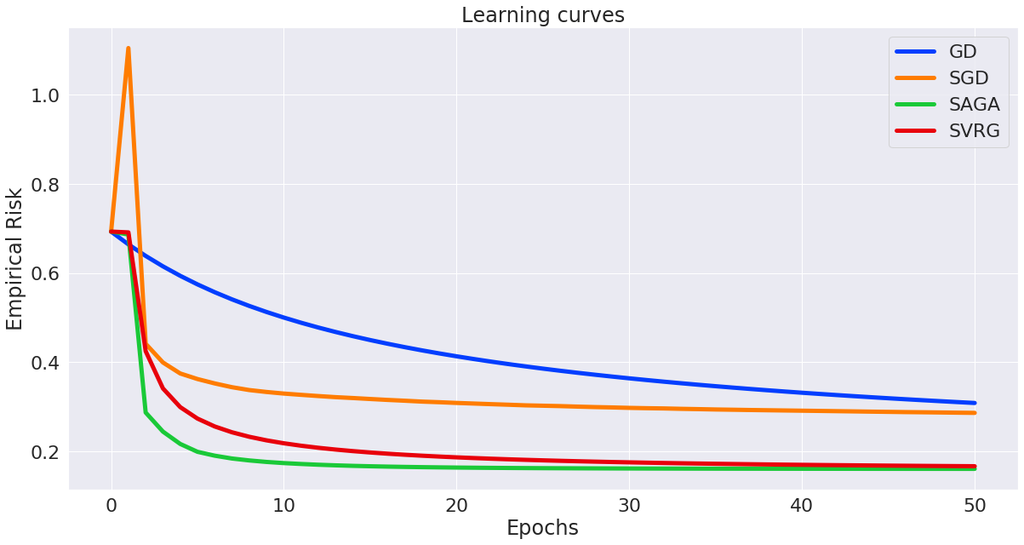

```
gd:	Accuracy on training set: 92.2%
	Accuracy on testing set:  84.8%
sgd:	Accuracy on training set: 88.2%
	Accuracy on testing set:  79.8%
saga:	Accuracy on training set: 95.6%
	Accuracy on testing set:  88.9%
svrg:	Accuracy on training set: 95.6%
	Accuracy on testing set:  87.9%
```

```python
learning_curve(GD=clf_gd, SGD=clf_sgd, SAGA=clf_saga, SVRG=clf_svrg)

for clf, name in zip([clf_gd, clf_sgd, clf_saga, clf_svrg], ['gd', 'sgd', 'saga', 'svrg']):
    print(name + ':' \
          + "\tAccuracy on training set: {0:0.1f}%".format(100*clf.score(A_train, b_train)))
    print("\tAccuracy on testing set:  {0:0.1f}%".format(100*clf.score(A_test, b_test)))
```

# IV. Regularization

**Question:**

- Rewrite the empirical risk minimization objective with both $L_1$ and $L_2$ regularization (with coefficients $l_1$ and $l_2$).
- Is this objective $\mu$-strongly convex, $L$-smooth, differentiable?
- Complete the **TODO (8)** to account for the new term in the objective.
- Add your code to **lib/linear_model.py**.

> **Answer:** New objective is $\ \textrm{min}_{x\in \mathbb{R}^d}\frac{1}{n_{\textrm{train}}} \sum_{i=1}^{n_{\textrm{train}}} \textrm{LogisticLoss}(b_i, \left\langle a_{i}, x\right\rangle ) + \frac{l_2}{2}\|x\|^{2}_2 + l_1 \lVert x \rVert_1$. New objective is $l_2$-strongly convex, non-differentiable.

```
self._empirical_risk = lambda x: sum(self._logistic_loss(A, b, x))/n \
                                 + self.l2/2.0 * np.linalg.norm(x,2) \
                                 + self.l1 * np.linalg.norm(x,ord = 1)
```

The minimization algorithms we've implemented have a slow rate of convergence for this new objective function. We will therefore use *proximal* variations of these algorithms.

**Question:** Using the $\textrm{prox}_{l_1 \|\cdot\|_1}$ operator, write down the $k^{th}$ step of proximal GD, proximal SGD, proximal SAGA, and proximal SVRG.

> **Answer:** at the k-th step

> **proximal GD**:

> $$ x_{k+1} \leftarrow \text{prox}_{\gamma l_1\lVert \cdot \rVert_1} (x_{k} - \gamma\nabla f(x_k)) $$

> **proximal SGD**:

> $$ \begin{cases} i \textrm{ chosen randomly in } \{1...n\}\\ x_{k+1} \leftarrow \text{prox}_{\gamma_k l_1\lVert \cdot \rVert_1} ( x_{k} - \gamma_k \nabla f_i(x_k) )\\ \end{cases} $$

> **proximal SAGA**:

> $$ \begin{cases} i \textrm{ chosen randomly in } \{1...n\}\\ x_{k+1} \leftarrow \text{prox}_{\gamma_k l_1\lVert \cdot \rVert_1} \Big( x_{k} - \gamma_k\big(\nabla f_i(x_k) - \alpha_i + \bar{\alpha}\big)\Big) \\ \bar{\alpha} \leftarrow \bar{\alpha} - \frac{\alpha_i}{n} + \frac{\nabla f_i(x)}{n}\\ \alpha_i \leftarrow \nabla f_i(x)\\ \end{cases} $$

> **proximal SVRG**:

> $$ \begin{cases} \textrm{Compute the batch gradient } \nabla f(x_k)\\ \textrm{Initialise }y_0 = x_k\\ \textrm{for m in 0...M-1: } \begin{cases} i \textrm{ chosen randomly in } \{1...n\} \\ y_{m+1} \leftarrow \text{prox}_{\gamma_k l_1\lVert \cdot \rVert_1} \Big( y_{m} - \gamma_k\big(\nabla f_i(y_m) - \nabla f_i(x_k) + \nabla f(x_k)) \Big) \end{cases}\\ x_{k+1} \leftarrow y_{M} \end{cases} $$

**Question:**

- Give a closed-form expression of $\textrm{prox}_{l_1 \|\cdot\|_1}$
- Complete **TODO (9)** (note that you can access the $l_1$ coefficient using **self.l1**).
- Add your code to **\lib\linear_model.py**.

> **Answer:** Let us define $\text{prox}_{\gamma \lVert \cdot \rVert_1} (x) \in \mathbb{R}^n$ s.t. $[\text{prox}_{\gamma \lVert \cdot \rVert_1} (x)]_i:= \begin{cases} x_i - \gamma, \text{ if } x_i > \gamma \\ x_i + \gamma, \text{ if } x_i < - \gamma\\ 0, \text{ if} -\gamma < x_i < \gamma \end{cases}$.

We can write down $[\text{prox}_{\gamma \lVert \cdot \rVert_1} (x)]_i$ in a compact form: $$[\text{prox}_{\gamma \lVert \cdot \rVert_1} (x)]_i = \text{sign}(x_i)\max(|x_i| - \gamma,0)$$

```python
def prox(x, stepsize):
    stepsize = self.l1*stepsize
    res = np.sign(x) * np.maximum(np.abs(x) - stepsize, 0)
    return res
```

**Question:**

- Add **prox** to the attributes of the solvers (both in the call to **self.solver** in **/lib/linear_model.py** and in **/lib/solvers.py**) as follows:  
  solver(x0, grad, **prox**, self.max_iter, n, L, mu)
- Add a proximal step to all the algorithms in **/lib/solvers.py**.
- Paste one of these algorithms in the cell bellow.

```python
def SGD(x0, grad, prox, max_iter, n, L, mu):
    x         = x0
    x_tab     = np.copy(x)
    c0 = 1.0
    for k in range(max_iter):
        gammak = c0/(k+1)
        i = np.random.randint(low=0, high=n)
        x = prox(x - gammak*grad(x,i=i), gammak)
        if k%n == 0: # each completed epoch
            x_tab = np.vstack((x_tab, x))
    return x, x_tab
```

**Question:** If your proximal gradient descent is correctly implemented, the following cell will plot the support of the solution for various values of $l_1$.

- Interpret the plot and explain what can $L_1$ regularization be used for.

> **Answer:** Bigger values of $l_1$ "induce" sparsity of the minimizer. This allows one to use prior about sparsity of the solution. It may be demonstrated that for certain problems $l_1$ allows recover exactly the sparse solution. In addition, $l_1$ regularization may be used for feature selection.

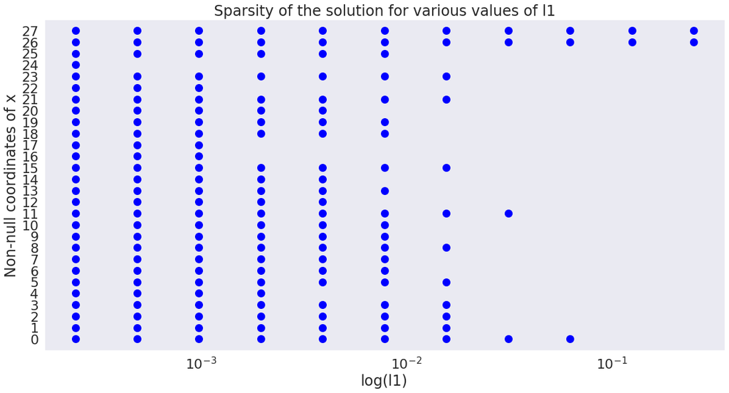

```python
from lib.visuals import l1_regularization_plot

clf = lambda l1: LogisticRegression(solver='gd', l1=l1, l2=0.1, max_iter=1000)

l1_regularization_plot(clf, A_train, b_train)
```

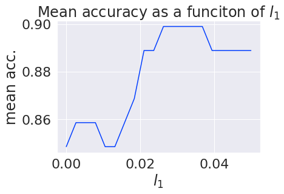

```python
from scipy import sparse
from sklearn import datasets
from sklearn.preprocessing import StandardScaler
from matplotlib import pyplot as plt

n_samples = 100
np.random.seed(1234)

l1_val = np.linspace(0,0.05, 20)
test_error = []

clf = lambda l1: LogisticRegression(solver='gd', l1=l1, l2=0.1, max_iter=50)

for l1_t in l1_val:
    clf_cur = clf(l1_t)
    clf_cur.fit(A_train, b_train)
    test_error.append(clf_cur.score(A_test, b_test))

plt.plot(l1_val, test_error)
plt.title(r"Mean accuracy as a funciton of $l_1$")
plt.ylabel('mean acc.')
plt.xlabel(r'$l_1$')
```

We see that regularization indeed helps.

**Question:** The following cell will plot the value of the coordinates of the solution for various values of $l_2$.

- Interpret the plot and explain what can $L_2$ regularization be used for.

> **Answer:** $l_2$ regularization "attracts" minimizer towards zero, affecting largest (by absolute value) coeficients the most. It also "helps" with optimization, conditioning or stabilizing optimization problem. Finally, both $l_1$ and $l_2$ regularizations correspond to certain priors we may have about the solution of the learning problem. Sometimes, this leads to better generalization and prevents overfitting.

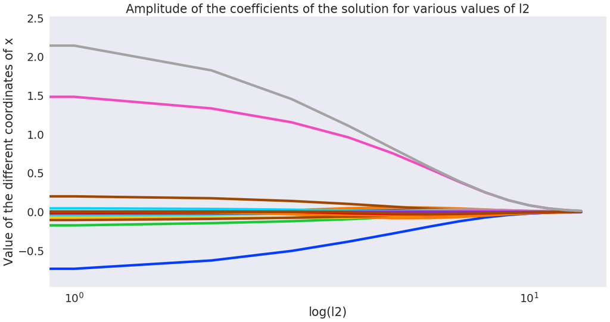

```python
from lib.visuals import l2_regularization_plot

clf = lambda l2: LogisticRegression(solver='gd', l1=0.01, l2=l2, max_iter=1000)

l2_regularization_plot(clf, A_train, b_train)
```

# V. Further development

We expect that you go beyond the lab's questions and that you develop certain aspects of your work, depending on your personal interests and skills, for instance:

- Implementations and numerical tests (further developments, more experiments, etc.)
- Applications in learning or statistics (interpretation of some results, other models, other datasets, etc.)
- Theoretical or mathematical questions (convergence proofs, convergence rates, advanced versions of an algorithm, theoretical analysis of special cases, etc.)

**Keyword ideas**: standard or stochastic Newton method, ADMM, continuation methods, tests on large scale datasets, intuition behind variance reduction, catalyst...

In this part we implement **Adaptive gradient algorithm** from a [recent paper](https://arxiv.org/pdf/1910.09529.pdf) by Malitsky et al and **(consensus) ADMM**.

We begin with **Adaptive gradient**.

The algorithm solves the following optimization problem ($f$ is differentiable) $$\min\limits_{x \in \mathbb{R}^d} f(x)$$ and proceeds as follows: As an input it takes intital guess $x^0 \in \mathbb{R}^d$, $\lambda_0 > 0$, $\theta_{0} = \infty$, $x^1 = x^0 - \lambda_0 \nabla f(x^0)$ and then iterates as described below (for $k = 1, \dots )$ $$ \begin{cases} \lambda_k = \min \left\{ \sqrt{1 + \frac{\theta_{k-1}}{2}} \lambda_{k-1}, \frac{\lVert x^k - x^{k-1}\rVert}{2\lVert \nabla f(x^k) - \nabla f(x^{k-1}\rVert} \right\}\\ x^{k+1} = x^k - \lambda_k \nabla f (x^k)\\ \theta_k = \frac {\lambda_k} {\lambda_{k-1}} \end{cases} $$

If the optimization problem has a solution, $f$ is convex and and has a locally Lipschitz gradient, then the algorithm achives convergence rate of $\mathcal{O}(\frac 1 k)$. Under additional assumption of $f$ being locally strongly convex, the sequence $x^k$ produced by the algorithm converges with a linear rate to the solution of the optimization problem $x^*$.

```python
def ADGRAD(x0, grad, prox_unsed, max_iter, n, L_unsed, mu_unsed):
    xm = np.copy(x0) #x_k-1
    x_tab = np.copy(xm)
    ld = 1.0 #lambda. We test several lambda0 and the results are similar, so initialization is not very imporant.
    theta = float('inf')
    x = xm - ld*grad(xm) #x_k
    for k in range(max_iter):
        ldp = min(np.sqrt(1 + theta/2.0)*ld,
                 np.linalg.norm(x - xm)/(2*np.linalg.norm(grad(x) - grad(xm))) )
        x, xm = x - ldp*grad(x), x
        theta = ldp/ld
        ld = ldp
        x_tab = np.vstack((x_tab, x))

    return x, x_tab
```

We implement the algorithm and compare it to the algorithms discussed before.

```
M 4
```

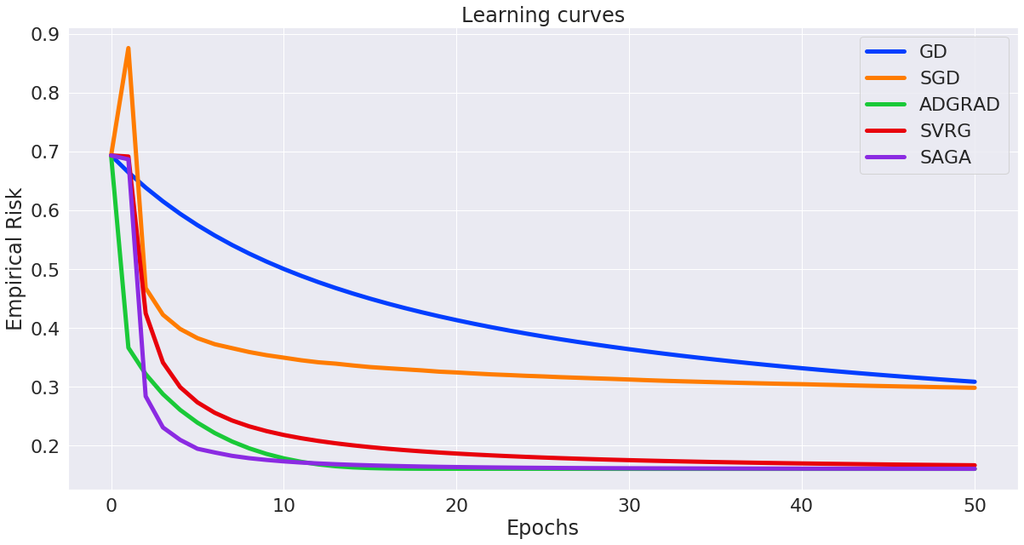

```python
epochs = 50
n = len(b_train)

M = 4 # number of iterations in the inner loop of svrg, need for plots

clf_gd   = LogisticRegression(solver='gd', l2=0.01, max_iter=epochs)
clf_sgd  = LogisticRegression(solver='sgd', l2=0.01, max_iter=epochs*n)
clf_adgrad   = LogisticRegression(solver='adgrad', l2=0.01, max_iter=epochs)
clf_svrg = LogisticRegression(solver='svrg', l2=0.01, max_iter=epochs*n//M)
clf_saga = LogisticRegression(solver='saga', l2=0.01, max_iter=epochs*n)

clf_gd.fit(A_train, b_train)
clf_sgd.fit(A_train, b_train)
clf_adgrad.fit(A_train, b_train)
clf_svrg.fit(A_train, b_train)
clf_saga.fit(A_train, b_train)


learning_curve(GD=clf_gd, SGD=clf_sgd, ADGRAD=clf_adgrad, SVRG=clf_svrg, SAGA=clf_saga)
```

```python
for clf, name in zip([clf_gd, clf_sgd, clf_saga, clf_svrg, clf_adgrad], ['gd', 'sgd', 'saga', 'svrg', 'adgrad']):
    print(name + ':' \
          + "\tAccuracy on training set: {0:0.1f}%".format(100*clf.score(A_train, b_train)))
    print("\tAccuracy on testing set:  {0:0.1f}%".format(100*clf.score(A_test, b_test)))
```

```
gd:	Accuracy on training set: 92.2%
	Accuracy on testing set:  84.8%
sgd:	Accuracy on training set: 87.2%
	Accuracy on testing set:  86.9%
saga:	Accuracy on training set: 95.6%
	Accuracy on testing set:  88.9%
svrg:	Accuracy on training set: 95.6%
	Accuracy on testing set:  87.9%
adgrad:	Accuracy on training set: 95.6%
	Accuracy on testing set:  88.9%
```

### Conclusion

We see that Adaptive Gradient algorithm indeed shows fast convergence and does not require an appropriately chosen stepsize to work.

## Consensus ADMM for logistic regression

More on ADMM : http://stanford.edu/class/ee364b/lectures/admm_slides.pdf .

Our goal is to solve optimization problem $$ \min\limits_{x \in \mathbb{R}^d} \sum\limits_{i=1}^N f_i(x) + g(x) $$

where $f_i$ corresponds to the non-regularized loss of the model (e.g. logistic regression) on an $i$-th block of the training data and $g$ is a regularizer. In case of the logistic regression, $$ f_i(x) = \frac{1}{n_{\text{train}}}\sum\limits_{j \in D_i} \left[ \textrm{LogisticLoss}(b_j, \left\langle a_{j}, x\right\rangle ) + \frac{l_2}{2}\lVert x \rVert^2 \right] $$ where $D_i$ is the $i$-th data block ($\sum_{i=1}^N |D_i| = n_{\text{train}}$), $g(x) = \lambda_1 \lVert x \rVert_1$.

For consensus ADMM we first reformulate the problem: $$ \min\limits_{x_1, \dots, x_N, z} \sum\limits_{i=1}^N f_i(x_i) + g(z) \text{ s.t. $x_1 = x_2 = \dots =x_N = z$} $$

ADMM proceeds iteratively.

Initialization: $x^0_i \in \mathbb{R}^d$, $y^0_i \in \mathbb{R}^d $ for $i = 1, \dots N$, $z^0 \in \mathbb{R}^d $, $\rho > 0$.

For $k=0, \dots$, (in parallel) over $i = 1, \dots N$

- $x^{k+1}_i = \underset{x_i}{\operatorname{argmin}} \left( f_i(x_i) + \left< y_i^k, x_i - z^k \right>
- \frac \rho 2 \lVert x_i - z^k \rVert^2 \right)$;
- [exchange $x_i^{k+1}$ between workers for $i=1, \dots, N$ (in the distributing setting)]
- $z^{k+1} = \operatorname{prox}_{ \frac {1} {N\rho} g} \left[ \frac 1 N \sum\limits_{i=1}^N \left( x^{k+1}_i + \frac 1 \rho y^k_i \right) \right]$;
- $y^{k+1}_i = y^k_i + \rho (x^{k+1}_i - z^{k+1})$.
- [exchange $y_i^{k+1}$ between workers for $i=1, \dots, N$ (in the distributing setting)]

Comments on **initialization**. The problem is unconstrained and convex so will converge with any initialization, so we initialize $x^0_i$, $y^0_i$, $z^0$ to zeros. The parameter $\rho$ corresponds to the cost of violation of the constraints and also regularizes the problem in a sense, and may be chosen using cross-validation. We set $\rho$ to $1.0$.

#### Implementation

```python
def ADGRAD_local(x0, grad, max_iter, tol = 1e-8):
    xm = np.copy(x0) #x_k-1
    x_tab = np.copy(xm)
    ld = 1.0 #lambda. We test several lambda0 and the results are similar, so initialization is not very imporant.
    theta = float('inf')
    x = xm - ld*grad(xm) #x_k
    gradm = grad(xm)
    for k in range(max_iter):
        gradcur = grad(x)
        ldp = min(np.sqrt(1 + theta/2.0)*ld,
                 np.linalg.norm(x - xm)/(2*np.linalg.norm(gradcur - gradm)) )
        x, xm = x - ldp*gradcur, x
        gradm = gradcur
        theta = ldp/ld
        ld = ldp
        x_tab = np.vstack((x_tab, x))
        if np.linalg.norm(gradm) < tol:
            break
    return x, x_tab
```

```python
def solve_local(A, b, x0, y, z, rho, l2, ntrain, maxiter_local=1000):
    def grad(x, i=None):
        '''
        Gradient of the objective function at x.
        If no i is given, grad should return the batch gradient.
        Otherwise, it should return the partial gradient associated the the datapoint (A[i], b[i]).
        '''

        if i is None: # return batch gradient
            output = -b/(1 + np.exp(b*np.dot(A, x)))
            output = sum(np.diag(output))/ntrain @ A

        else: # return partial gradient associated the datapoint (A[i], b[i])
            output = -b[i]*A[i]/(1 + np.exp(b[i]*(A[i]@x)))

        output += l2*x * len(b)/ntrain

        return output + y + rho*(x - z)

    x, x_tab_discard = ADGRAD_local(x0, grad, maxiter_local)
    return x

def split_data(A, b, N):
    ntrain, d = A.shape
    return np.array_split(A, N), np.array_split(b, N)


def admm(A_train, b_train, rho =1.0, N = 2, maxiter = 1000, l2 = 0.01, l1=0.0, maxiter_local=1000):
    ntrain, d = A_train.shape
    x = np.zeros((N, d))
    x_tab = np.copy(x)
    y = np.zeros((N,d))
    z = np.zeros(d)
    z_tab = np.copy(z)
    A, b = split_data(A_train, b_train, N)

    for k in range(maxiter):
        for worker in range(N): # compute local updates "in parallel"
            x[worker] = solve_local(A[worker], b[worker], x[worker], y[worker],
                                    z, rho, l2, ntrain, maxiter_local)
        # exchange x_i
        z = prox((np.sum(x, axis = 0) + np.sum(y,axis=0)/rho)/N, l1/(N*rho))
        z_tab = np.vstack((z_tab, z))
        for worker in range(N): # compute local updates "in parallel"
            y[worker] = y[worker] + rho*(x[worker] - z)

        # exchange y_i
        x_tab = np.vstack((x_tab, x))
    return x, x_tab, z_tab
```

```python
class LogRegressionADMM(LogisticRegression):
    def __init__(self, l1=0.0, l2=0.01, maxiter_admm = 100, maxiter_local=1000, rho=1.0, N=4):
        self.l1 = l1
        self.l2 = l2
        self.maxiter_admm = maxiter_admm
        self.maxiter_local = maxiter_local
        self.rho=rho
        self.N=N
    def fit(self, A_train, b_train):
        n = len(b_train)
        self.coef_, self._coef_tab_local ,self._coef_tab = admm(A_train, b_train, rho=self.rho,
                                                                N=self.N, maxiter=self.maxiter_admm,
                                                                l2=self.l2, l1=self.l1,
                                                                maxiter_local=self.maxiter_local)
        self._empirical_risk = lambda x: sum(self._logistic_loss(A_train, b_train, x))/n \
                                         + self.l2/2.0 * np.linalg.norm(x,2) + self.l1*np.linalg.norm(x,1)
```

#### Visuals

```python
def compute_residuals(xtab, N):
    n, d = xtab.shape
    l = n//N
    xtab_res = xtab.reshape(l, N, d)
    xtab_av = np.average(xtab_res, axis=(1))
    xtab_av_tiles = np.repeat(xtab_av,N,axis=0)
    res = xtab - xtab_av_tiles
    return res
```

```python
def plot_iteration_residuals(clf):
    plt.figure(figsize=(10,10))
    residuals = compute_residuals(clf._coef_tab_local, clf.N)
    res_norms = np.linalg.norm(residuals, axis =1)
    iters = len(res_norms)//clf.N
    for worker in range(clf.N):
        plt.plot(np.arange(iters), res_norms[worker::clf.N], label=f'Worker {worker+1}', linewidth=2.0)

    plt.plot(np.arange(iters), np.linalg.norm(clf._coef_tab - clf._coef_tab_local[::clf.N], axis=1),
        linewidth=2.0, marker='s', ms=4.0, color='black', label=r"$\Vert \bar{x}^k - z^k \Vert_2$")

    plt.title(r"Consensus residuals")
    plt.ylabel(r"$\Vert \bar{x}^k - . \Vert_2$")
    plt.xlabel('iteration k')
    plt.yscale('log')
    plt.legend()
    plt.grid(True)
    plt.show()
```

### Experiments

```python
clf_admm = LogRegressionADMM(l1=0.005,l2=0.005)
clf_admm.fit(A_train, b_train)

epochs = 100
n = len(b_train)
clf_gd   = LogisticRegression(solver='gd', max_iter=epochs)
clf_sgd  = LogisticRegression(solver='sgd', max_iter=epochs*n)
for clf in [clf_gd, clf_sgd]:
    clf.fit(A_train, b_train)
```

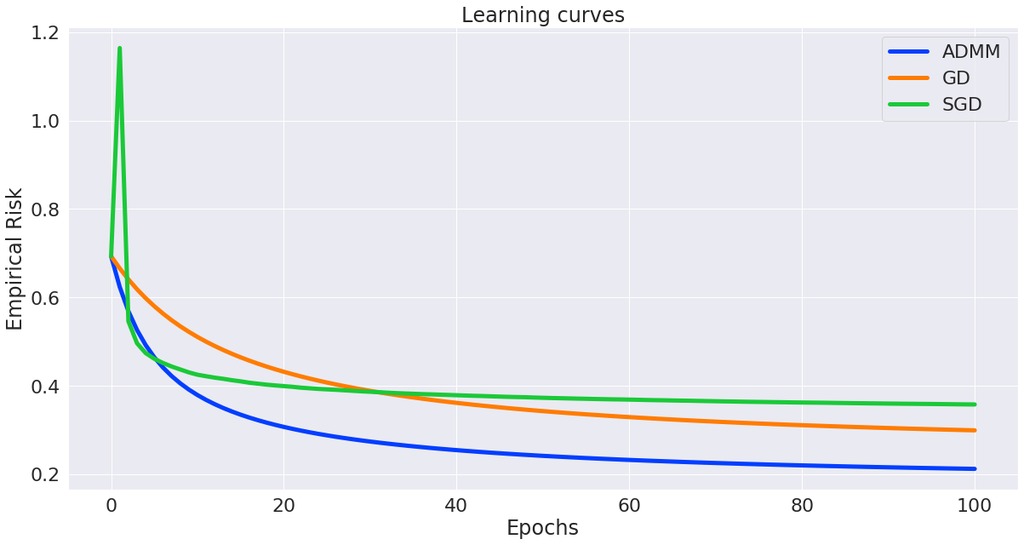

```python
learning_curve(ADMM=clf_admm, GD=clf_gd, SGD=clf_sgd)
```

#### Comments

We can also see how the local approximations of the workers converge (to their avarage):

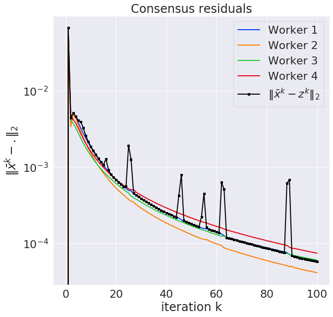

```python
plot_iteration_residuals(clf_admm)
```